# Assignment Machine Learning

# Weight Lifting Quality Prediction

### Synopsis

Exercise is becoming an important part of general health for individuals in the US and developed countries. Specifically, tracking the amount of exercise completed in a given time frame has been the focus of most fitness tracking devices. However, the future of exercise tracking will be determining the quality of exercise in addition to the quantity. This study will reference previously recorded exercise data in an attempt to predict quality of exercise given certain exercise data variables.

### Data Processing and Exploration

The data utilized was sourced from the following site [Human Activity Recognition and Weight Lifting Exercises](http://groupware.les.inf.puc-rio.br/har). Below shows the code used to read in the data from the HAR website.

```r
library(ElemStatLearn)
library(AppliedPredictiveModeling)
library(caret)
library(dplyr)
library(ggplot2)
setwd("/Users/Barb/R/Machine Learning/Assignment")
wleTrain<-read.csv("wle.csv",header=TRUE,sep=",")
set.seed(33833)
```

The data was filtered to include only acceleration variables and sliced into a more managable data set.

```r
wleTrain2<-select(wleTrain,contains("accel"),contains("classe"))
wleTrain3<-select(wleTrain2,-contains("var"))
InTrain<-createDataPartition(y=wleTrain3$classe,p=0.3,list=FALSE)
wleTrain3<-wleTrain3[InTrain,]
wleTest3<-wleTrain3[-InTrain,]
```

The data was examined and exploratory plots were drawn with R. The most significant plot that showed some interesting trends was plotting the *accel dumbbell y* vs *accel belt z* variables shown below.

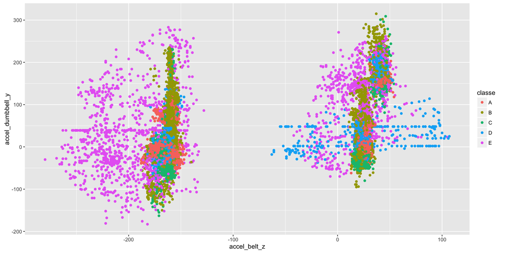